# Анализ финансирования стартапов и инвестиционных стратегий

**Автор**: Стогниева Дарья Александровна

**Дата**: 02.02.2026

## Введение

### Цели и задачи проекта

**Цель проекта:** подготовить датасет к работе, исследовать динамику и структуру финансирования стартапов и ответить на вопросы, важные для оценки инвестиционных стратегий.

**Задачи проекта:**

1. Провести предобработку данных: убрать дубликаты и пропуски, проверить корректность числовых и временных значений.
2. Выделить группы компаний по срокам финансирования и сравнить их по количеству и объёму инвестиций.
3. Классифицировать сегменты рынка на массовые, средние и нишевые и учесть это в дальнейшем анализе.
4. Определить типичные и аномальные значения объёмов финансирования, исключить выбросы и ограничить период исследования.
5. Сравнить популярность и объёмы разных типов финансирования.
6. Проанализировать динамику раундов и объёмов инвестиций по годам, а также изменения в массовых сегментах рынка.
7. Рассчитать долю возврата средств для разных типов финансирования и оценить её устойчивость.
8. Подвести итоговые выводы и дать рекомендации, куда и каким образом было бы целесообразно инвестировать, если бы на дворе был 2015 год.

### Описание данных

Датасет получен из базы данных стартапов.

Название основного датасета — `cb_investments.zip`. Внутри архива один файл — `cb_investments.csv`.

Описание данных:

- `name` — название компании.
- `homepage_url` — ссылка на сайт компании.
- `category_list` — категории, в которых работает компания. Указываются через `|`.
- `market` — основной рынок или отрасль компании.
- `funding_total_usd` — общий объём привлечённых инвестиций в долларах США.
- `status` — текущий статус компании, например `operating`, `closed` и так далее.
- `country_code` — код страны, например USA.
- `state_code` — код штата или региона, например, CA.
- `region` — регион, например, SF Bay Area.
- `city` — город, в котором расположена компания.
- `funding_rounds` — общее число раундов финансирования.
- `participants` — число участников в раундах финансирования.
- `founded_at` — дата основания компании.
- `founded_month` — месяц основания в формате `YYYY-MM`.
- `founded_quarter` — квартал основания в формате `YYYY-QN`.
- `founded_year` — год основания.
- `first_funding_at` — дата первого финансирования.
- `mid_funding_at` — дата среднего по времени раунда финансирования.
- `last_funding_at` — дата последнего финансирования.
- `seed` — сумма инвестиций на посевной стадии.
- `venture` — сумма венчурных инвестиций.
- `equity_crowdfunding` — сумма, привлечённая через долевой краудфандинг.
- `undisclosed` — сумма финансирования нераскрытого типа.
- `convertible_note` — сумма инвестиций через конвертируемые займы.
- `debt_financing` — сумма долгового финансирования.
- `angel` — сумма инвестиций от бизнес-ангелов.
- `grant` — сумма полученных грантов.
- `private_equity` — сумма инвестиций в виде прямых (частных) вложений.
- `post_ipo_equity` — сумма финансирования после IPO.
- `post_ipo_debt` — сумма долгового финансирования после IPO.
- `secondary_market` — сумма сделок на вторичном рынке.
- `product_crowdfunding` — сумма, привлечённая через продуктовый краудфандинг.
- `round_A` — `round_H` — сумма инвестиций в соответствующем раунде.

Название дополнительного датасета — `cb_returns.csv`. Он содержит суммы возвратов по типам финансирования в миллионах долларов по годам.

Описание данных:

- `year` — год возврата средств.
- `seed` — сумма возвратов от посевных инвестиций.
- `venture` — сумма возвратов от венчурных инвестиций.
- `equity_crowdfunding` — сумма, возвращённая по долевому краудфандингу.
- `undisclosed` — сумма возвратов нераскрытого типа.
- `convertible_note` — сумма возвратов через конвертируемые займы.
- `debt_financing` — сумма возвратов от долгового финансирования.
- `angel` — сумма возвратов бизнес-ангелам.
- `grant` — сумма возвратов по грантам.
- `private_equity` — сумма возвратов прямых (частных) вложений.
- `post_ipo_equity` — сумма возвратов от IPO.
- `post_ipo_debt` — сумма возвратов от долгового IPO.
- `secondary_market` — сумма возвратов от сделок на вторичном рынке.
- `product_crowdfunding` — сумма возвратов по продуктовому краудфандингу.

### Содержимое проекта

Шаг 1: Загрузка и предобработка данных

- Загрузить необходимые библиотеки и данные по проекту.
- Изучить структуру датасетов: объём данных, типы столбцов, наличие пропусков, соответствие данных описанию.
- Привести названия столбцов к единому аккуратному стилю.
- Преобразовать типы данных.
- Обработать пропуски при необходимости.
- Удалить полные дубликаты.

Шаг 2: Инжиниринг признаков

- Разделить компании на группы по срокам финансирования.
- Проанализировать распределение количества компаний и объёма привлечённых инвестиций по группам.
- Провести сегментацию рынка.

Шаг 3: Работа с выбросами и аналитический анализ

- Оценить типичный и аномальный объём общего финансирования (funding_total_usd) с помощью визуального анализа.
- Выявить компании с аномальным объёмом финансирования методом IQR отдельно по каждому сегменту рынка.
- Определить сегменты с наибольшей долей аномального финансирования.
- Проверить полноту данных за 2014 год и исключить компании с аномальными значениями.
- Ограничить выборку компаниями, которые получали финансирование в годы с высокой инвестиционной активностью (50+ раундов).

Шаг 4: Анализ типов финансирования

- Проанализировать типы финансирования.
- Сравнить объём и частоту использования типов финансирования.
- Проанализировать суммарные объёмы возвратов средств по типам финансирования.

Шаг 5: Анализ динамики

- Рассчитать средний объём одного раунда финансирования для каждой компании.
- Проанализировать по годам динамику типичного размера одного раунда и динамику общего количества раундов финансирования.
- Определить массовые сегменты рынка, показавшие рост финансирования в 2014 году, и проанализировать динамику их развития.
- Рассчитать нормированные показатели возврата средств по годам и типам финансирования, обработав аномальные значения.
- Построить графики для ключевых типов финансирования и сделать выводы об устойчивости роста показателей.

Шаг 6: Итоговый вывод и рекомендации

- Подвести итоги проделанной работы и описать основные этапы анализа.
- Сформулировать ключевые выводы о динамике рынка, сегментах и типах финансирования.
- Дать рекомендации заказчику (на 2015 год) по перспективным отраслям для инвестиций и наиболее уместным типам финансирования.

## Шаг 1. Знакомство с данными: загрузка и предобработка

### 1.1. Вывод общей информации

Загрузим необходимые для работы библиотеки.

```python
# Импортируем библиотеки pandas, matplotlib и seaborn:
import pandas as pd
import numpy as np

# Загружаем библиотеки для визуализации данных
import matplotlib.pyplot as plt
```

Загрузим все данные по проекту.

```python
# Выгружаем датасет cb_investments.csv из архива:
df = pd.read_csv("https://code.s3.yandex.net/datasets/cb_investments.zip", sep=';', low_memory=False)

# Выгружаем датасет cb_returns.csv:
cb_returns = pd.read_csv("https://code.s3.yandex.net/datasets/cb_returns.csv")
```

Перед тем как начать преобработку данных, ознакомимся с данными датафреймов `df` и `cb_returns`.

```python
# Выводим первые строки датафрейма df на экран
df.head(5)
```

|  | name | homepage_url | category_list | market | funding_total_usd | status | country_code | state_code | region | city | ... | secondary_market | product_crowdfunding | round_A | round_B | round_C | round_D | round_E | round_F | round_G | round_H |
| --- | --- | --- | --- | --- | --- | --- | --- | --- | --- | --- | --- | --- | --- | --- | --- | --- | --- | --- | --- | --- | --- |
| 0 | Harvard University | http://harvard.edu | \|Education\| | Education | 9,00,00,000 | operating | USA | MA | Boston | Cambridge | ... | 0.0 | 0.0 | 0.0 | 0.0 | 0.0 | 0.0 | 0.0 | 0.0 | 0.0 | 0.0 |
| 1 | University of New Brunswick | http://www.unb.ca | NaN | NaN | 20,00,000 | operating | NaN | NaN | NaN | NaN | ... | 0.0 | 0.0 | 0.0 | 0.0 | 0.0 | 0.0 | 0.0 | 0.0 | 0.0 | 0.0 |
| 2 | DuPont | http://www.dupont.com | \|Business Services\|Agriculture\|Automotive\|Inve... | Business Services | 90,00,000 | operating | USA | DE | Wilmington, Delaware | Wilmington | ... | 0.0 | 0.0 | 0.0 | 0.0 | 0.0 | 0.0 | 0.0 | 0.0 | 0.0 | 0.0 |
| 3 | University of Michigan | http://www.umich.edu/ | \|Education\| | Education | 77,00,000 | operating | USA | MI | Detroit | Ann Arbor | ... | 0.0 | 0.0 | 0.0 | 0.0 | 0.0 | 0.0 | 0.0 | 0.0 | 0.0 | 0.0 |
| 4 | Case Western Reserve University | http://www.case.edu | \|Education\| | Education | 5,40,000 | operating | USA | OH | Cleveland | Cleveland | ... | 0.0 | 0.0 | 0.0 | 0.0 | 0.0 | 0.0 | 0.0 | 0.0 | 0.0 | 0.0 |

5 rows × 40 columns

```python
# Выведем информацию о датафрейме с помощью метода info()
df.info()
```

```
<class 'pandas.core.frame.DataFrame'>
RangeIndex: 54294 entries, 0 to 54293
Data columns (total 40 columns):
 #   Column                Non-Null Count  Dtype
---  ------                --------------  -----
 0   name                  49437 non-null  object
 1   homepage_url          45989 non-null  object
 2   category_list         45477 non-null  object
 3    market               45477 non-null  object
 4    funding_total_usd    49438 non-null  object
 5   status                48124 non-null  object
 6   country_code          44165 non-null  object
 7   state_code            30161 non-null  object
 8   region                44165 non-null  object
 9   city                  43322 non-null  object
```

[output cut: 32 more lines]

Датафрейм `df` содержит 40 столбцов и 54294 строки, в которых представлена информация о компаниях и состоявшемся финансировании. Судя по первому знакомству с данными, значения в столбцах соответствуют своему описанию. Все данные представлены типами float64 и object.

В столбцах 'market' и 'funding_total_usd' видны отступы перед названием столбцов. Поэтому необходимо избавиться от лишних пробелов на этапе предобработки данных.

**Столбцы с некорректным типом данных**

- 'funding_total_usd' - содержит числовые значения с разделителями разрядов, необходимо удалить разделители и привести к типу float.
- 'founded_at', 'founded_month', 'founded_quarter', 'first_funding_at', 'mid_funding_at', 'last_funding_at' - содержат даты и должны быть приведены к типу datetime.
- 'founded_year' приведем из float64 в int64 после обработки пропусков.

**Столбцы с пропущенными значениями**

Пропуски обнаружены в следующих столбцах: 'name', 'homepage_url', 'category_list', 'market', 'status', 'country_code', 'state_code', 'region', 'city','participants', 'founded_at', 'founded_month', 'founded_quarter', 'founded_year', mid_funding_at', 'funding_total_usd'.

```python
# Выведем первые 5 строк датафрейма cb_returns на экран:
cb_returns.head(5)
```

|  | year | seed | venture | equity_crowdfunding | undisclosed | convertible_note | debt_financing | angel | grant | private_equity | post_ipo_equity | post_ipo_debt | secondary_market | product_crowdfunding |
| --- | --- | --- | --- | --- | --- | --- | --- | --- | --- | --- | --- | --- | --- | --- |
| 0 | 2000 | 16.70 | 55.40 | 0.0 | 78.21 | 0.00 | 8.66 | 6.43 | 0.0 | 0.00 | 0.94 | 0.0 | 0.20 | 0.0 |
| 1 | 2001 | 2.88 | 23.49 | 0.0 | 21.50 | 0.01 | 4.49 | 1.18 | 0.0 | 0.00 | 0.46 | 0.0 | 0.46 | 0.0 |
| 2 | 2002 | 6.59 | 209.42 | 0.0 | 25.77 | 0.02 | 3.42 | 3.41 | 0.0 | 1.51 | 0.34 | 0.0 | 0.06 | 0.0 |
| 3 | 2003 | 7.74 | 233.86 | 0.0 | 9.40 | 0.01 | 1.09 | 3.41 | 0.0 | 1.62 | 2.11 | 0.0 | 0.08 | 0.0 |
| 4 | 2004 | 9.93 | 555.90 | 0.0 | 33.19 | 0.01 | 13.55 | 9.18 | 0.0 | 2.19 | 3.38 | 0.0 | 0.55 | 0.0 |

```python
# Выведем информацию о датафрейме с помощью метода info()
cb_returns.info()
```

```
<class 'pandas.core.frame.DataFrame'>
RangeIndex: 15 entries, 0 to 14
Data columns (total 14 columns):
 #   Column                Non-Null Count  Dtype
---  ------                --------------  -----
 0   year                  15 non-null     int64
 1   seed                  15 non-null     float64
 2   venture               15 non-null     float64
 3   equity_crowdfunding   15 non-null     float64
 4   undisclosed           15 non-null     float64
 5   convertible_note      15 non-null     float64
 6   debt_financing        15 non-null     float64
 7   angel                 15 non-null     float64
 8   grant                 15 non-null     float64
 9   private_equity        15 non-null     float64
 10  post_ipo_equity       15 non-null     float64
 11  post_ipo_debt         15 non-null     float64
 12  secondary_market      15 non-null     float64
 13  product_crowdfunding  15 non-null     float64
dtypes: float64(13), int64(1)
memory usage: 1.8 KB
```

Датафрейм cb_returns содержит 14 столбцов и 15 строк, в которых представлена информация об объёмах возвратов по годам и типам финансирования в миллионах долларов. Данные соответствуют описанию.

Все столбцы, кроме 'year', имеют тип float64. К тому же, все столбцы датасета имеют корректный тип данных.

Пропущенные значения в датасете отсутствуют - все столбцы заполнены полностью.

Перед анализом необходимо установить столбец 'year' в качестве индекса датафрейма.

```python
# сохраним количество строк исходного датасета для возможности проверить сделанные изменения после предобработки
tmp = len(df)
tmp
```

```
54294
```

### 1.2. Предобработка данных

Как мы ранее отметили, названия некоторых столбцов датасета `df` требуют переформатирования. Уберем лишние отступы в названии столбцов и приведем их к нижнему регистру.

```python
# Уберем лишние пробелы в названиях столбцов с помощью .str.strip()
df.columns = df.columns.str.strip()

# Приведем все названия столбцов к нижнему регистру с помощью .str.lower()
df.columns = df.columns.str.lower()

# Проверим, как теперь выглядят столбцы 'market' и 'funding_total_usd'
df.columns
```

```
Index(['name', 'homepage_url', 'category_list', 'market', 'funding_total_usd',
       'status', 'country_code', 'state_code', 'region', 'city',
       'funding_rounds', 'participants', 'founded_at', 'founded_month',
       'founded_quarter', 'founded_year', 'first_funding_at', 'mid_funding_at',
       'last_funding_at', 'seed', 'venture', 'equity_crowdfunding',
       'undisclosed', 'convertible_note', 'debt_financing', 'angel', 'grant',
       'private_equity', 'post_ipo_equity', 'post_ipo_debt',
       'secondary_market', 'product_crowdfunding', 'round_a', 'round_b',
       'round_c', 'round_d', 'round_e', 'round_f', 'round_g', 'round_h'],
      dtype='object')
```

Теперь формат названий столбцов идентичен для всех!

Однако, значения в столбцах могут быть написаны в разных форматах и, тем самым, дублироваться. Так как столбец `market` пригодится нам в дальнейшем анализе, и нам не стоит искажать результаты, проверим уникальные значения в этом столбце.

```python
# Воспользуемся методом .unique() чтобы посмотреть уникальные значения в столбце 'market'
df['market'].unique()
```

```
array([' Education ', nan, ' Business Services ', ' Social Media ',
       ' Hardware + Software ', ' Biotechnology ', ' Hardware + Software',
       ' Utilities ', ' Hospitality ', ' Enterprise Software ',
       ' Manufacturing ', ' Pharmaceuticals ', 'Finance', 'Shipping',
       ' Finance ', ' Design ', ' Nonprofits ', ' Software ',
       ' Curated Web ', ' Health Care ', ' Education',
       ' Health and Wellness ', ' Media ', ' Politics ',
       ' Clean Technology ', 'Manufacturing', ' Financial Services ',
       ' Consumer Electronics ', ' Web Hosting ', 'E-Commerce',
       ' Automotive ', ' Local Businesses ', ' E-Commerce ', ' Medical ',
       ' Fashion ', ' Advanced Materials ', ' Banking ', 'Security ',
       ' Publishing ', ' Networking ', ' Analytics ', ' Semiconductors ',
       ' Public Relations ', ' Energy ', ' Cosmetics ', ' Jewelry ',
       ' Nanotechnology ', ' Travel ', ' Retail',
       ' Public Transportation ', 'Consulting ', ' Security ',
       ' Construction ', ' Real Estate ', ' Consulting ',
       'Environmental Innovation ', ' Retail ', ' Restaurants ',
       ' Services ', ' Technology ', ' Telecommunications ',
       ' Insurance ', ' Information Technology ', ' Legal ',
       'Hospitality', 'Health Care Information Technology',
       'Curated Web ', ' Music ', ' Advertising ', 'Payments', ' Games ',
       ' Mobile ', ' Consumer Goods ', 'Services  ', ' Sports ',
       'Hardware + Software', ' Events ', ' Medical Devices ',
       ' Electronics ', ' Real Estate  ', 'Networking  ', ' Construction',
       ' Games', ' Human Resources ', 'E-Commerce ', ' Venture Capital ',
       ' Payments ', 'Storage ', 'Medical', 'Software', ' Non Profit ',
       ' Manufacturing  ', ' Internet ', ' Wireless ', 'Software ',
       ' Finance Technology ', ' Hardware ', ' Internet Marketing ',
       'E-Commerce  ', ' Photography ', 'Internet Marketing', ' News ',
       'News', 'Retail', ' Messaging ', ' Mobile Payments ',
       ' Enterprises  ', ' Search ', 'Education', 'Semiconductors',
       ' Consumers ', ' Hospitals ', ' Manufacturing', ' Video ',
       ' Mobile', ' Transportation ', ' Enterprise Software  ',
       ' Governments ', ' Web Development ', ' Marketplaces ',
       ' Market Research ', 'Internet ', ' Oil & Gas ', ' Enterprises ',
       'Biotechnology ', ' Location Based Services ', 'Security',
       ' Broadcasting ', ' Entertainment ', 'Software  ', ' SaaS ',
       ' Internet of Things ', 'Energy ', ' Storage ', ' iPhone ',
       'Clean Technology ', ' Hardware + Software  ', ' Video Streaming ',
       ' Software', ' Cloud Computing  ', 'Consulting', ' VoIP ',
```

[output cut: 234 more lines]

```
       ' Mobile Software Tools ', ' Telecommunications',
       ' Digital Entertainment ', 'Pharmaceuticals', 'Energy Efficiency ',
       ' Interior Design ', ' Comics ', ' Assisitive Technology ',
       ' Natural Gas Uses ', ' Clinical Trials ',
       'Private Social Networking ', ' Energy Efficiency',
       'Point of Sale ', ' Veterinary ', ' Lighting ',
       'Business Intelligence ', ' Employment ',
       ' Real Estate Investors ', 'Services', 'Android',
       ' Pharmaceuticals', ' Services  ', ' Predictive Analytics',
       ' Infrastructure ', ' Business Productivity ', 'Medical  ',
       ' Internet of Things  ', ' Colleges ', 'Therapeutics',
       'Peer-to-Peer  ', ' Leisure', ' Search Marketing ', ' Creative ',
       ' Mining Technologies ', ' Telecommunications  ',
       ' Consumer Goods', ' Musicians ', ' Location Based Services',
       ' Social + Mobile + Local ', ' Hotels ', ' Gold '], dtype=object)
```

Хотя значений очень много, можно заметить, что в значениях есть лишние пробелы и многие значения дублируются. Чтобы в дальнейшем был более точный результат по каждому сегменту рынка, приведем значение к единному формату.

Чтобы потом сравнить результат, посчитаем изначальное количество уникальных значений в столбце:

```python
df['market'].nunique()
```

```
939
```

```python
# Чтобы убрать лишние пробелы в значениях, воспользуемся методом .strip()
df['market'] = df['market'].str.strip()

# Приведем все значения к нижнему регистру
df['market'] = df['market'].str.lower()

# Еше раз посчитаем уникальные значения:
df['market'].nunique()
```

```
439
```

Количество уникальных значений в столбце `market` сократилось на 500 единиц. Это более чем в 2 раза.

Продолжим преобработку данных и уберем в столбце `funding_total_usd` выделение разрядов и приведем его к числовому типу.

```python
# Уберем выделение разрядов в столбце с помощью .str.replace():
df['funding_total_usd'] = df['funding_total_usd'].str.replace(',','')


# Приведем данные в столбце к числовому типу с помощью pd.to_numeric() и все нечисловые значения заменим на пропуски:
df['funding_total_usd'] = pd.to_numeric(df['funding_total_usd'],errors='coerce')

# Выведем информацию о датафрейме
df.info()
```

```
<class 'pandas.core.frame.DataFrame'>
RangeIndex: 54294 entries, 0 to 54293
Data columns (total 40 columns):
 #   Column                Non-Null Count  Dtype
---  ------                --------------  -----
 0   name                  49437 non-null  object
 1   homepage_url          45989 non-null  object
 2   category_list         45477 non-null  object
 3   market                45477 non-null  object
 4   funding_total_usd     40907 non-null  float64
 5   status                48124 non-null  object
 6   country_code          44165 non-null  object
 7   state_code            30161 non-null  object
 8   region                44165 non-null  object
 9   city                  43322 non-null  object
```

[output cut: 32 more lines]

```python
# Также, выведем первые 5 строк датафрейма и посмотрим, как теперь выглядят значения в столбце
df.head(5)
```

|  | name | homepage_url | category_list | market | funding_total_usd | status | country_code | state_code | region | city | ... | secondary_market | product_crowdfunding | round_a | round_b | round_c | round_d | round_e | round_f | round_g | round_h |
| --- | --- | --- | --- | --- | --- | --- | --- | --- | --- | --- | --- | --- | --- | --- | --- | --- | --- | --- | --- | --- | --- |
| 0 | Harvard University | http://harvard.edu | \|Education\| | education | 90000000.0 | operating | USA | MA | Boston | Cambridge | ... | 0.0 | 0.0 | 0.0 | 0.0 | 0.0 | 0.0 | 0.0 | 0.0 | 0.0 | 0.0 |
| 1 | University of New Brunswick | http://www.unb.ca | NaN | NaN | 2000000.0 | operating | NaN | NaN | NaN | NaN | ... | 0.0 | 0.0 | 0.0 | 0.0 | 0.0 | 0.0 | 0.0 | 0.0 | 0.0 | 0.0 |
| 2 | DuPont | http://www.dupont.com | \|Business Services\|Agriculture\|Automotive\|Inve... | business services | 9000000.0 | operating | USA | DE | Wilmington, Delaware | Wilmington | ... | 0.0 | 0.0 | 0.0 | 0.0 | 0.0 | 0.0 | 0.0 | 0.0 | 0.0 | 0.0 |
| 3 | University of Michigan | http://www.umich.edu/ | \|Education\| | education | 7700000.0 | operating | USA | MI | Detroit | Ann Arbor | ... | 0.0 | 0.0 | 0.0 | 0.0 | 0.0 | 0.0 | 0.0 | 0.0 | 0.0 | 0.0 |
| 4 | Case Western Reserve University | http://www.case.edu | \|Education\| | education | 540000.0 | operating | USA | OH | Cleveland | Cleveland | ... | 0.0 | 0.0 | 0.0 | 0.0 | 0.0 | 0.0 | 0.0 | 0.0 | 0.0 | 0.0 |

5 rows × 40 columns

После обработки, столбец выглядит лучше и значения теперь хранятся в числовом типе данных. Однако, стоит заметить, что количество пропущенных значений значительно увеличилось. Вероятно, некоторые пропущенные значения были заполнены изначально знаком "-".

Следующим шагом обработаем типы данных в столбцах, которые хранят значения даты и времени. К таким столбцам относятся 'founded_at', 'first_funding_at', 'mid_funding_at' и 'last_funding_at'.

```python
# Создадим список столбцов, в которых нужно изменить тип данных на временной:
dates = ['founded_at', 'first_funding_at', 'mid_funding_at', 'last_funding_at']

# Создадим цикл чтобы конвертировать типы данных
for column in dates:
    df[column] = pd.to_datetime(df[column], errors='coerce')

# Проверяем результат
df[dates].info()
```

```
<class 'pandas.core.frame.DataFrame'>
RangeIndex: 54294 entries, 0 to 54293
Data columns (total 4 columns):
 #   Column            Non-Null Count  Dtype
---  ------            --------------  -----
 0   founded_at        38553 non-null  datetime64[ns]
 1   first_funding_at  49428 non-null  datetime64[ns]
 2   mid_funding_at    30288 non-null  datetime64[ns]
 3   last_funding_at   49432 non-null  datetime64[ns]
dtypes: datetime64[ns](4)
memory usage: 1.7 MB
```

Все значения во временных столбцах теперь хранятся в правильном типе данных.

Дальше, в датасете `cb_returns` сделаем столбец `year` индексом всего датасета.

```python
# Для этого воспользуемся методом .set_index()
cb_returns = cb_returns.set_index('year')

# Проверим все ли верно получилось:
cb_returns.head(5)
```

| year | seed | venture | equity_crowdfunding | undisclosed | convertible_note | debt_financing | angel | grant | private_equity | post_ipo_equity | post_ipo_debt | secondary_market | product_crowdfunding |
| --- | --- | --- | --- | --- | --- | --- | --- | --- | --- | --- | --- | --- | --- |
| 2000 | 16.70 | 55.40 | 0.0 | 78.21 | 0.00 | 8.66 | 6.43 | 0.0 | 0.00 | 0.94 | 0.0 | 0.20 | 0.0 |
| 2001 | 2.88 | 23.49 | 0.0 | 21.50 | 0.01 | 4.49 | 1.18 | 0.0 | 0.00 | 0.46 | 0.0 | 0.46 | 0.0 |
| 2002 | 6.59 | 209.42 | 0.0 | 25.77 | 0.02 | 3.42 | 3.41 | 0.0 | 1.51 | 0.34 | 0.0 | 0.06 | 0.0 |
| 2003 | 7.74 | 233.86 | 0.0 | 9.40 | 0.01 | 1.09 | 3.41 | 0.0 | 1.62 | 2.11 | 0.0 | 0.08 | 0.0 |
| 2004 | 9.93 | 555.90 | 0.0 | 33.19 | 0.01 | 13.55 | 9.18 | 0.0 | 2.19 | 3.38 | 0.0 | 0.55 | 0.0 |

```python
df['participants'].head(5)
```

```
0    NaN
1    NaN
2    1.0
3    0.0
4    NaN
Name: participants, dtype: float64
```

Теперь, столбец с годами является индексом датафрейма `cb_returns`.

Обработаем текстовые данные в столбцах 'name', 'homepage_url', 'category_list', 'market', 'status', 'country_code', 'state_code', 'region', 'city'. Пропуски в текстовых столбцах заполним заглушкой "Неизвестно".

```python
# Создадим список с названиями столбцов, которые содержат текстовые данные
text_columns = ['name', 'homepage_url', 'category_list', 'market', 'status', 'country_code', 'state_code', 'region', 'city']

# Создадим цикл чтобы заменить пропуски значением "Неизвестно"
for column in text_columns:
    df[column] = df[column].fillna('Неизвестно')

# Проверяем результат
df[text_columns].info()
```

```
<class 'pandas.core.frame.DataFrame'>
RangeIndex: 54294 entries, 0 to 54293
Data columns (total 9 columns):
 #   Column         Non-Null Count  Dtype
---  ------         --------------  -----
 0   name           54294 non-null  object
 1   homepage_url   54294 non-null  object
 2   category_list  54294 non-null  object
 3   market         54294 non-null  object
 4   status         54294 non-null  object
 5   country_code   54294 non-null  object
 6   state_code     54294 non-null  object
 7   region         54294 non-null  object
 8   city           54294 non-null  object
dtypes: object(9)
memory usage: 3.7+ MB
```

Пропусков в этих столбцах больше нет.

Обработаем полные дубликаты в данных и пропуски в `funding_total_usd`. Избавимся от тех строк, которые не несут какой-либо информации, либо не содержат данных о финансировании.

```python
# Проверяем полные дубликаты в датафрейме
df.duplicated().sum()
```

```
4855
```

```python
# Целых 4855 строк с полными дубликатами, удалим их:
df = df.drop_duplicates()

# Проверяем полные дубликаты в датафрейме
df.duplicated().sum()
```

```
0
```

```python
# Проверим также, значения в столбцах name и homepage_url, они должны быть уникальными:
# Проверяем неявные дубликаты в датафрейме по столбцам 'name' и 'homepage_url'
df.duplicated(subset=['name','homepage_url']).sum()
```

```
12
```

```python
# Удалим 12 неявных дублирующихся строк:
df = df.drop_duplicates(subset=['name','homepage_url'], keep='first', inplace=False)

df.duplicated(subset=['name','homepage_url']).sum()
```

```
0
```

Теперь удалим строки, которые не содержат данных о финансировании:

```python
# Сначала удалим строки с пропущеными значениями в столбце 'funding_total_usd':
df = df.dropna(subset=['funding_total_usd'])
```

В датасете могут быть компании, у которых:

- funding_total_usd = 0
- и при этом нет ни одного раунда финансирования

Такие строки тоже не несут полезной информации для анализа инвестиций, удалим их.

```python
# Отфильтруем строки в которых значение funding_total_usd не равно 0 и есть информация о раунде финансирования:
df = df[(df['funding_total_usd'] > 0) & (df['funding_rounds'] > 0)]
```

```python
# Проверим результат
df.info()
```

```
<class 'pandas.core.frame.DataFrame'>
Int64Index: 40896 entries, 0 to 49437
Data columns (total 40 columns):
 #   Column                Non-Null Count  Dtype
---  ------                --------------  -----
 0   name                  40896 non-null  object
 1   homepage_url          40896 non-null  object
 2   category_list         40896 non-null  object
 3   market                40896 non-null  object
 4   funding_total_usd     40896 non-null  float64
 5   status                40896 non-null  object
 6   country_code          40896 non-null  object
 7   state_code            40896 non-null  object
 8   region                40896 non-null  object
 9   city                  40896 non-null  object
```

[output cut: 32 more lines]

Пропуски остались в столбцах `participants`, `founded_at`, `founded_month`, `founded_quarter`, `founded_year`, `first_funding_at` и `mid_funding_at`.

Перед тем как определить, что мы можем сделать с пропусками в этих столбцах, ознакомимся с количеством пропуском в абсолютном и относительном значениях.

```python
# Для вывода пропущенных значений создадим функцию show_missing_stats, которая отобразит количество пропусков в абсолютном и относительном значениях
def show_missing_stats(tmp0):
    missing_stats = pd.DataFrame({
        'Кол-во пропусков': tmp0.isnull().sum(),
        'Доля пропусков': tmp0.isnull().mean()
    })
    missing_stats = missing_stats[missing_stats['Кол-во пропусков'] > 0]

    if missing_stats.empty:
        return "Пропусков в данных нет"

# Форматируем при выводе через Styler
    return (missing_stats.style.format({'Доля пропусков': '{:.6f}'}))
show_missing_stats(df)
```

|  | Кол-во пропусков | Доля пропусков |
| --- | --- | --- |
| participants | 13572 | 0.331866 |
| founded_at | 8704 | 0.212833 |
| founded_month | 8769 | 0.214422 |
| founded_quarter | 8769 | 0.214422 |
| founded_year | 8703 | 0.212808 |
| first_funding_at | 2 | 0.000049 |
| mid_funding_at | 13672 | 0.334311 |

Во всех столбцах, кроме `first_funding_at`, количество пропущенных значений составляет более 20%, поэтому:

- строки с пропусками в `first_funding_at` удалим, так их всего 2 и это не сильно исказит анализ.
- строки с пропусками в `participants`, `founded_at`, `founded_month`, `founded_quarter` и `founded_year` мы проигнорируем, так как эти столбцы мы не будем использовать в дальнейшем анализе.
- пропуски в значениях `mid_funding_at` заполним на основании значений в столбцах `first_funding_at` и `last_funding_at`.

```python
# Удалим строки с пропущеными значениями в столбце 'first_funding_at':
df = df.dropna(subset=['first_funding_at'])
```

Теперь, заполним пропуски в значениях `mid_funding_at` на основании значений в столбцах `first_funding_at` и `last_funding_at`. В качестве нового значения вместо пропусков возьмем приблизительно середину интервала между этими двумя датами.

```python
# Находим строки с пропусками в mid_funding_at
mid_funding_null = df['mid_funding_at'].isna()

# Заполняем пропуски серединой интервала
df.loc[mid_funding_null, 'mid_funding_at'] = (df.loc[mid_funding_null, 'first_funding_at'] +
    (df.loc[mid_funding_null, 'last_funding_at'] -
     df.loc[mid_funding_null, 'first_funding_at']) / 2)
```

```python
# Оценим размер оставшихся пропусков в столбце.
df['mid_funding_at'].isna().mean()
```

```
0.0
```

Процент пропущенных значений в столбце `mid_funding_at` равен 0.

```python
# Выведем информацию о датафрейме
df.info()
```

```
<class 'pandas.core.frame.DataFrame'>
Int64Index: 40894 entries, 0 to 49437
Data columns (total 40 columns):
 #   Column                Non-Null Count  Dtype
---  ------                --------------  -----
 0   name                  40894 non-null  object
 1   homepage_url          40894 non-null  object
 2   category_list         40894 non-null  object
 3   market                40894 non-null  object
 4   funding_total_usd     40894 non-null  float64
 5   status                40894 non-null  object
 6   country_code          40894 non-null  object
 7   state_code            40894 non-null  object
 8   region                40894 non-null  object
 9   city                  40894 non-null  object
```

[output cut: 32 more lines]

Судя по полученным данным, пропуски остались только в тех столбцах, где мы их проигнорировали.

Узнаем, какой процент данных был отброшен?

```python
# Проверим сколько удалено строк датасета
a, b = tmp, len(df)
print(" Было строк в исходном датасете", a,
      '\n', "Осталось строк в датасете после обработки", b,
      '\n', "Удалено строк в датасете после обработки", a-b,
      '\n', "Процент потерь", round((a-b)/a*100, 2))
```

```
 Было строк в исходном датасете 54294
 Осталось строк в датасете после обработки 40894
 Удалено строк в датасете после обработки 13400
 Процент потерь 24.68
```

### Промежуточный вывод

В ходе загрузки и предобработки данных были выполнены следующие шаги:

1. Вывод общей информации:
- Выгрузили все необходимые для выполнения проекта библиотеки;
- Загрузили датасеты с данными;
- Озакомились с данными с помощью методов `.head(5)` и `.info()`.
1. Предобработка данных:
- Убрали лишние отступы в названиях столбцов датасета df и привели их к нижнему регистру;
- В столбце `funding_total_usd` убрали выделение разрядов и привели значения в этом столбце к числовому типу данных;
- Значения в столбцах `founded_at`, `first_funding_at`, `mid_funding_at` и `last_funding_at` привели к типу datetime64;
- В датасете `cb_returns` сделали столбец `year` индексом всего датасета;
- Пропуски в текстовых столбцах `name`, `homepage_url`, `category_list`, `market`, `status`, `country_code`, `state_code`, `region`, `city` заполнили заглушкой "Неизвестно";
- Проверили и удалили 4855 строк с явными дубликатами;
- Проверили и удалили 12 строк с неявными дубликатами;
- Удалили строки, которые не несут в себе никакой информации, или не содержат данные о финансировании;
- Удалили 2 строки с пропусками в first_funding_at;
- Пропуски в столбцах `participants`, `founded_at`, `founded_month`, `founded_quarter` и `founded_year` проигнорировали;
- Пропуски в столбце `mid_funding_at` заполнили на основании значений `first_funding_at` и `last_funding_at`.

**Результаты предобработки:**

- Было строк в исходном датасете: 54294;
- Осталось строк в датасете после обработки: 40894;
- Удалено строк в датасете после обработки 13400;
- Процент потерь: 24.68%.

## Шаг 2. Инжиниринг признаков

### 2.1. Группы по срокам финансирования

На данном этапе, разделим все компании на 3 группы:

- Единичное финансирование — был всего один раунд финансирования.
- Срок финансирования до года — между первым и последним раундом финансирования прошло не более года.
- Срок финансирования более года.

Для начала, сделаем так, чтобы для всех визуализаций была использована единая цветовая схема:

- единичное финансирование — розовый цвет,
- срок финансирования до года — оранжевый,
- срок финансирования более года — жёлтый.

```python
# Создадим словарь цветов:
colors = {
    'Единичное финансирование': '#fc0fc0',
    'Срок финансирования до года': '#ff7f0e',
    'Срок финансирования более года': '#ffba00'
}
```

```python
# Создадим функцию, чтобы разделить компании на группы по срокам финансирования
def funding_group(row):
    if row['funding_rounds'] == 1:
        return 'Единичное финансирование'

    duration = (row['last_funding_at'] - row['first_funding_at']).days

    if duration <= 365:
        return 'Срок финансирования до года'
    else:
        return 'Срок финансирования более года'

# Создадим столбец 'funding_group' и применим функцию к датафрейму:
df['funding_group'] = df.apply(funding_group,axis=1)

# Проверим результат
df.head(5)
```

|  | name | homepage_url | category_list | market | funding_total_usd | status | country_code | state_code | region | city | ... | product_crowdfunding | round_a | round_b | round_c | round_d | round_e | round_f | round_g | round_h | funding_group |
| --- | --- | --- | --- | --- | --- | --- | --- | --- | --- | --- | --- | --- | --- | --- | --- | --- | --- | --- | --- | --- | --- |
| 0 | Harvard University | http://harvard.edu | \|Education\| | education | 90000000.0 | operating | USA | MA | Boston | Cambridge | ... | 0.0 | 0.0 | 0.0 | 0.0 | 0.0 | 0.0 | 0.0 | 0.0 | 0.0 | Единичное финансирование |
| 1 | University of New Brunswick | http://www.unb.ca | Неизвестно | Неизвестно | 2000000.0 | operating | Неизвестно | Неизвестно | Неизвестно | Неизвестно | ... | 0.0 | 0.0 | 0.0 | 0.0 | 0.0 | 0.0 | 0.0 | 0.0 | 0.0 | Единичное финансирование |
| 2 | DuPont | http://www.dupont.com | \|Business Services\|Agriculture\|Automotive\|Inve... | business services | 9000000.0 | operating | USA | DE | Wilmington, Delaware | Wilmington | ... | 0.0 | 0.0 | 0.0 | 0.0 | 0.0 | 0.0 | 0.0 | 0.0 | 0.0 | Единичное финансирование |
| 3 | University of Michigan | http://www.umich.edu/ | \|Education\| | education | 7700000.0 | operating | USA | MI | Detroit | Ann Arbor | ... | 0.0 | 0.0 | 0.0 | 0.0 | 0.0 | 0.0 | 0.0 | 0.0 | 0.0 | Срок финансирования до года |
| 4 | Case Western Reserve University | http://www.case.edu | \|Education\| | education | 540000.0 | operating | USA | OH | Cleveland | Cleveland | ... | 0.0 | 0.0 | 0.0 | 0.0 | 0.0 | 0.0 | 0.0 | 0.0 | 0.0 | Единичное финансирование |

5 rows × 41 columns

В рамках инжиниринга признаков для каждой компании был создан новый столбец `funding_group`, отражающий срок финансирования. Категория определялась на основе количества раундов и длительности периода между первым и последним финансированием.

Теперь, мы можем визуализировать соотношение этих групп, создав два графика:

- По количеству компаний: Покажите, какой процент от общего числа компаний относится к каждой из трёх групп.
- По объёму инвестиций: Отобразите, какую долю от общего объёма привлечённых средств получила каждая группа.

Сначала, создадим график соотношения групп финансирования по количеству компаний.

```python
# Посчитаем количество компаний для каждой категории в относительном значении:
group_counts = df['funding_group'].value_counts(normalize=True)

# Выведем результат
group_counts
```

```
Единичное финансирование          0.589475
Срок финансирования более года    0.300509
Срок финансирования до года       0.110016
Name: funding_group, dtype: float64
```

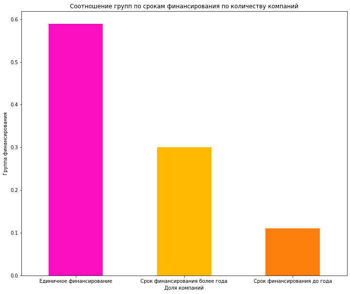

```python
# Построим график столбчатой диаграммы на основе group_counts
group_counts.plot(kind='bar',
               title=f'Соотношение групп по срокам финансирования по количеству компаний',
               legend=False,
               ylabel='Группа финансирования',
               xlabel='Доля компаний',
               figsize=(12, 10),
               rot=0,
               color=[colors[group] for group in group_counts.index])

# Выводим график
plt.show()
```

Судя по графику, компании ограничиваются либо одним раундом финансирования(59% компаний), либо получают финансировании в течение длительного времени (более года) - 30% компаний. Финасирование до года встречается значительно реже - всего в 11% компаний.

Построим график соотношения групп финансирования по объему инвестиций.

```python
# Посчитаем сумму инвестиций для каждой группы финансирования:
group_funding = (df.groupby('funding_group')['funding_total_usd'].sum())

# Определим, какую долю от общего объёма привлечённых средств получила каждая группа
group_funding_share = group_funding / group_funding.sum()

# Выведем результат
group_funding_share
```

```
funding_group
Единичное финансирование          0.306185
Срок финансирования более года    0.618709
Срок финансирования до года       0.075107
Name: funding_total_usd, dtype: float64
```

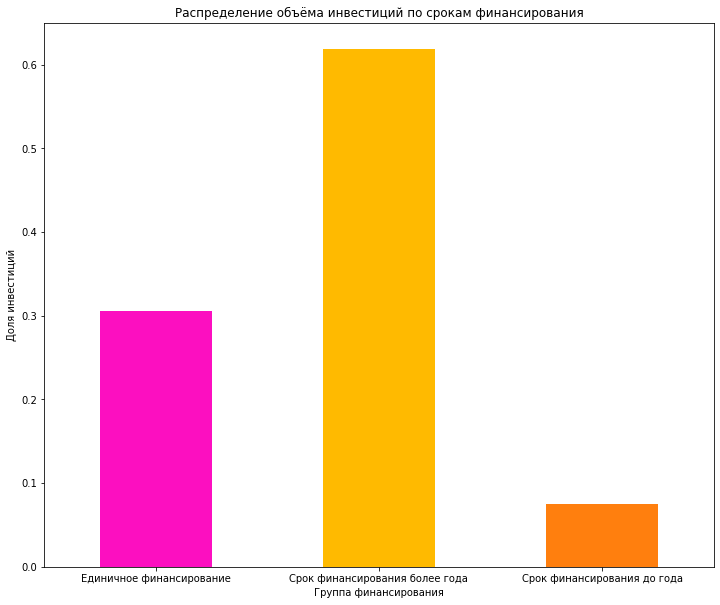

```python
# Построим график столбчатой диаграммы на основе group_funding_share
group_funding_share.plot(
    kind='bar',
    title='Распределение объёма инвестиций по срокам финансирования',
    legend=False,
    ylabel='Доля инвестиций',
    xlabel='Группа финансирования',
    figsize=(12, 10),
    rot=0,
    color=[colors[group] for group in group_funding_share.index])

# Выводим график
plt.show()
```

Большинство компаний относится к группе с единичным раундом финансирования или к компаниям со сроком финансирования от одного года. При этом наибольшая доля общего объёма инвестиций приходится на компании, которые привлекали финансирование в течение более длительного периода — более одного года.

Это указывает на то, что компании с долгосрочной историей привлечения инвестиций аккумулируют существенно большие объёмы финансирования(61%) по сравнению с компаниями с коротким сроком привлечения средств(30% и 7%).

### 2.2 Выделение средних и нишевых сегментов рынка

Чтобы выделить средние и нишевые сегменты рынка, по столбцу `market` рассчитаем, как часто в датасете встречается каждый из сегментов. Сегменты разделем на 3 категории:

- те, к которым относится более 120 компаний, отнесем к массовым;
- сегменты, в которые входит от 35 до 120 включительно, отнесем к средним;
- сегменты до 35 компаний отнесем к нишевым.

```python
# Сначала отфильтруем значение "Неизвестно", которым мы заменили пропуски на этапе предобработки
filtered_df = df[df['market'] != 'Неизвестно'].copy()
```

```python
# Посчитаем количество компаний для каждого сегмента рынка и сохраним в переменную market_counts
market_counts = filtered_df['market'].value_counts()
```

```python
# Разделим сегменты на массовые, средние и нишевые:
# Создаем словарь с количеством компаний по сегментам
market_dict = market_counts.to_dict()

# Создаем функцию для определения категории сегмента
def categorize_segment(market):
    count = market_dict.get(market, 0)
    if count > 120:
        return 'массовый'
    elif count >= 35:
        return 'средний'
    else:
        return 'нишевый'

# Добавляем столбец с категорией
filtered_df['segment_category'] = filtered_df['market'].apply(categorize_segment)

# Считаем количество сегментов каждой категории
segment_stats = filtered_df['segment_category'].value_counts()

# Выводим результат
segment_stats
```

```
массовый    33727
средний      3836
нишевый       830
Name: segment_category, dtype: int64
```

Для визуализации результата, построим график распределения количества компаний в сегментах и отобразим на нём разделение на нишевые и средние сегменты.

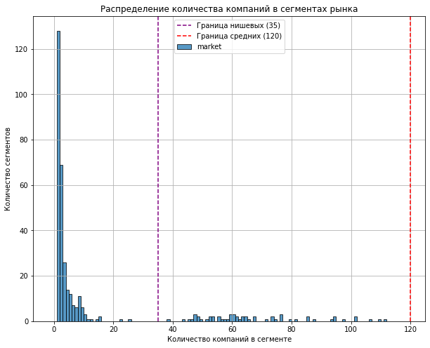

```python
plt.figure(figsize=(10, 8))

market_counts.plot(
    kind='hist',
    bins=range(-1,120), # Задаем лимит, чтобы исключить массовые сегменты
    alpha=0.75,
    edgecolor='black'
)

# Границы категорий
plt.axvline(x=35, color='purple', linestyle='--', label='Граница нишевых (35)')
plt.axvline(x=120, color='red', linestyle='--', label='Граница средних (120)')

# Оформление
plt.title('Распределение количества компаний в сегментах рынка')
plt.xlabel('Количество компаний в сегменте')
plt.ylabel('Количество сегментов')
plt.legend()
plt.grid()

plt.show()
```

Для дальнейшего анализа оставим в столбце `market` только массовые сегменты. Для остальных сегментов заменим значения на заглушки `niche` для нишевых и `mid` для средних.

```python
# Создадим функцию, чтобы выделить массовые сегменты, а в остальным заменить значения на заглушки
def simplify_market(market):
    count = market_counts.get(market, 0)
    if count > 120:
        return market
    elif count >= 35:
        return 'mid'
    else:
        return 'niche'

df['market'] = df['market'].apply(simplify_market)

# Проверим результат
df['market'].value_counts()
```

```
software                4812
mid                     3836
biotechnology           3590
niche                   3331
mobile                  2343
e-commerce              1865
curated web             1692
enterprise software     1381
health care             1185
clean technology        1180
games                   1116
advertising             1107
hardware + software     1062
social media            1003
health and wellness      872
education                844
finance                  828
analytics                667
manufacturing            596
security                 567
semiconductors           484
web hosting              424
consulting               349
hospitality              336
travel                   330
fashion                  303
news                     301
messaging                295
search                   291
real estate              279
saas                     271
music                    264
internet                 241
technology               238
apps                     223
photography              204
sports                   204
marketplaces             196
video                    188
social network media     158
automotive               155
cloud computing          152
medical                  151
big data                 150
entertainment            150
networking               143
nonprofits               135
design                   135
public relations         134
startups                 133
Name: market, dtype: int64
```

## Шаг 3. Работа с выбросами и анализ

### 3.1. Анализируем и помечаем выбросы в каждом из сегментов

Нас интересует обычный для рассматриваемого периода размер средств, который предоставлялся компаниям.

Построим гистограмму и диаграмму размаха для столбца `funding_total_usd` чтобы оценить, какой размер общего финансирования для одной компании будет типичным, а какой — выбивающимся.

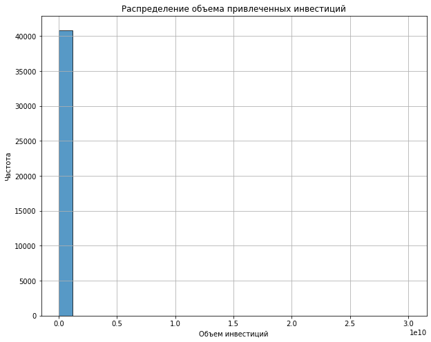

```python
# Создаём контейнер графика matplotlib и задаём его размер
plt.figure(figsize=(10, 8))

# Строим гистограмму с помощью pandas через plot(kind='hist')
df['funding_total_usd'].plot(
                kind='hist',
                bins=25,
                alpha=0.75,
                edgecolor='black',
                rot=0,
)

# Настраиваем оформление графика
plt.title('Распределение объема привлеченных инвестиций')
plt.xlabel('Объем инвестиций')
plt.ylabel('Частота')
# Добавляем сетку графика
plt.grid()

# Выводим график
plt.show()
```

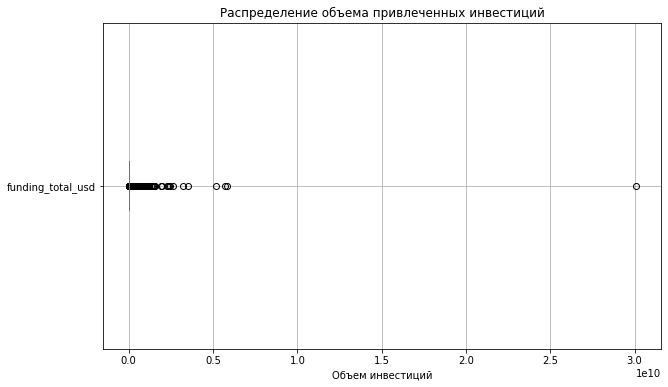

```python
# Создаём контейнер графика matplotlib и задаём его размер
plt.figure(figsize=(10, 6))

# Строим диаграмму размаха значений в столбце seats
df.boxplot(column='funding_total_usd', vert=False)

# Добавляем заголовок и метки оси
plt.title('Распределение объема привлеченных инвестиций')
plt.xlabel('Объем инвестиций')

# Выводим график
plt.show()
```

С помощью IQR найдем интервал, в котором лежат типичные значения.

```python
# Считаем Q1 и Q3
Q1 = df['funding_total_usd'].quantile(0.25)
Q3 = df['funding_total_usd'].quantile(0.75)

# Вычисляем IQR
IQR = Q3 - Q1

# Определяем верхнюю и нижнюю границы нормальных значений
lower_bound = Q1 - 1.5 * IQR
upper_bound = Q3 + 1.5 * IQR

# Выводим результат
print(f'Типичный размер финансирования находится в интервале {Q1} - {Q3}')
print(f'Аномальные значения: ниже {lower_bound} или выше {upper_bound}')
```

```
Типичный размер финансирования находится в интервале 350000.0 - 10000000.0
Аномальные значения: ниже -14125000.0 или выше 24475000.0
```

По boxplot-графику видно, что распределение общего объёма финансирования сильно скошено, и сделать какие либо выводы по графику будет трудно. Поэтому, мы посчитали межквартильный интервал (IQR). Согласно IQR:

Типичные значения общего финансирования одной компании лежат в интервале между первым и третьим квартилями — от 350000.0 до 10000000.0 долларов.

Значения, превышающие верхнюю границу межквартильного размаха (24475000.0 долларов), можно считать аномально высокими и относящимися к выбросам.

Определим компании с аномальным объёмом общего финансирования - применим метод IQR отдельно по каждому сегменту.

```python
# Для каждого сегмента считаем Q1 и Q3
def mark_outliers(group):
    Q1 = group['funding_total_usd'].quantile(0.25)
    Q3 = group['funding_total_usd'].quantile(0.75)
    # Считаем IQR
    IQR = Q3 - Q1

    # Определяем нижнию и верхнию границы
    lower_bound = Q1 - 1.5 * IQR
    upper_bound = Q3 + 1.5 * IQR

    # Помечаем выбросы
    group['is_outlier'] = ((group['funding_total_usd'] < lower_bound) | (group['funding_total_usd'] > upper_bound))

    return group

# Применяем по сегментам:
df_outliers = df.groupby('market', group_keys=False).apply(mark_outliers)
```

Определим сегменты рынка с наибольшей долей компаний, получивших аномальное финансирование, и выведем топ таких сегментов.

```python
# Рассчитываем для каждого сегмента долю компаний, получивших аномальное финансирование и сортируем в порядке убывания
outlier_stats = (df_outliers.groupby('market')['is_outlier'].mean().sort_values(ascending=False))

# Выводим топ-10 сегментов рынка
outlier_stats.head(10)
```

```
market
real estate        0.172043
entertainment      0.166667
consulting         0.166189
search             0.164948
cloud computing    0.164474
saas               0.162362
photography        0.161765
technology         0.159664
video              0.159574
travel             0.154545
Name: is_outlier, dtype: float64
```

### 3.2 Определяем границы рассматриваемого периода, отбрасываем аномалии

Проверим по датасету, можно ли считать, что данные за 2014 год - полные.

```python
# Создадим столбец с годом финансирования
df_outliers['funding_year'] = df_outliers['mid_funding_at'].dt.year

# Посмотрим количество компаний по годам
companies_by_year = df_outliers.groupby('funding_year')['name'].count()

# Выведем количество компаний по всем годам
companies_by_year.sort_index()
```

```
funding_year
1921       1
1960       2
1979       1
1982       3
1983       1
1984       2
1985       3
1987       2
1989       1
1990       1
1992       4
1993       1
1994       4
1995       4
```

[output cut: 20 more lines]

В 2014 году довольно большое количество компаний получили финансирование - 6615, это меньше по сравнению с предыдущим годом, но больше чем в 2012 году почти на 600. Исходя из этого, можно предположить, что данные за 2014 год - полные.

Теперь исключим из датасета компании, которые мы ранее посчитали получившими аномальное финансирование.

```python
# Оставляем только неаномальные компании
df_clean = df_outliers[df_outliers['is_outlier'] == False].copy()
```

После того, как мы исключили аномальные записи, на основе столбцов `mid_funding_at` и `funding_rounds` оставим в датасете данные только об определённых компаниях. Они должны были получать финансирование в годы, когда было зафиксировано 50 или более раундов финансирования.

```python
# Считаем количество раундов по годам
rounds_by_year = (df_clean.groupby('funding_year')['funding_rounds'].sum())
```

```python
# Выбираем активные годы
active_years = rounds_by_year[rounds_by_year >= 50].index

# Выводим результат
active_years
```

```
Int64Index([2000, 2001, 2002, 2003, 2004, 2005, 2006, 2007, 2008, 2009, 2010,
            2011, 2012, 2013, 2014],
           dtype='int64', name='funding_year')
```

Активными будем считать 2000-2014 годы.

```python
# Фильтруем датасет
df_final = df_clean[df_clean['funding_year'].isin(active_years)].copy()
```

### 3.3. Анализ типов финансирования по объёму и популярности

Построим график, который покажет, какие типы финансирования в сумме привлекли больше всего денег. Будем ориентироваться на значения в столбцах `seed`, `venture`, `equity_crowdfunding`, `undisclosed`, `convertible_note`, `debt_financing`, `angel`, `grant`, `private_equity`, `post_ipo_equity`, `post_ipo_debt`, `secondary_market` и `product_crowdfunding`.

```python
# Создадим список столбцов с типами финансирования
funding_types = ['seed', 'venture','equity_crowdfunding','undisclosed','convertible_note','debt_financing','angel','grant','private_equity','post_ipo_equity','post_ipo_debt','secondary_market','product_crowdfunding']

# Посчитаем суммарный объем средств по каждому типу финансирования
funding_volume = df_final[funding_types].sum().sort_values(ascending=False)

# Выведем результат
funding_volume
```

```
venture                 1.290734e+11
seed                    9.435951e+09
debt_financing          8.193778e+09
private_equity          4.830725e+09
angel                   2.477724e+09
undisclosed             2.088889e+09
grant                   2.002124e+09
post_ipo_equity         1.930552e+09
convertible_note        5.660394e+08
post_ipo_debt           2.867183e+08
equity_crowdfunding     2.379606e+08
product_crowdfunding    1.833103e+08
secondary_market        4.528580e+07
dtype: float64
```

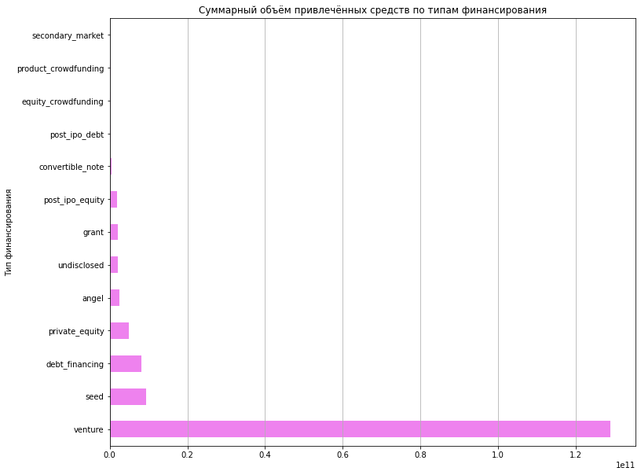

```python
# Построим линейчатую диаграмму
funding_volume.plot(kind='barh',
    title='Суммарный объём привлечённых средств по типам финансирования',
    legend=False,
    xlabel='Тип финансирования',
    ylabel='Сумма возвратов, млн $',
    figsize=(12, 10),
    rot=0,
    color='violet')

plt.grid(axis='x')

plt.show()
```

Судя по графику, наибольшую часть денег привлекли венчурные инвестиции. Также в тройке лидиров инвестиции на посевной стадии и долговое финансирование.

Также, построим график, который покажет популярность разных типов финансирования: какие типы финансирования чаще всего используются компаниями, то есть встречаются в датасете наибольшее количество раз.

```python
funding_popularity = (df_final[funding_types] > 0).sum().sort_values(ascending=False)

funding_popularity
```

```
venture                 18835
seed                    13368
debt_financing           3269
angel                    2934
grant                    1005
undisclosed               814
private_equity            636
convertible_note          521
equity_crowdfunding       515
product_crowdfunding      204
post_ipo_equity           163
post_ipo_debt              27
secondary_market            7
dtype: int64
```

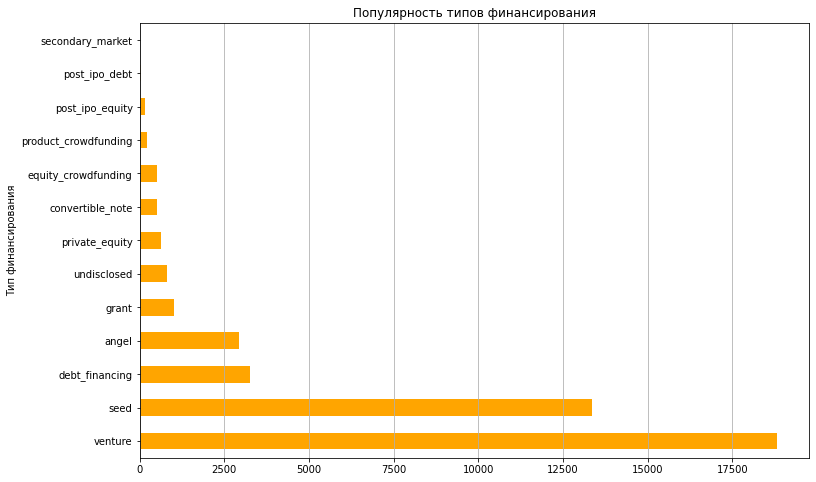

```python
# Построим столбчатую диаграмму для визуализации популярности
funding_popularity.plot(kind='barh',
    title='Популярность типов финансирования',
    legend=False,
    xlabel='Тип финансирования',
    ylabel='Количество лет с ненулевыми значениями',
    figsize=(12, 8),
    rot=0,
    color='orange')

plt.grid(axis='x')

plt.show()
```

Построим график суммарных объёмов возвратов от разных типов финансирования за весь период на основе дополнительного датасета `cb_returns`.

```python
# Вычисляем суммарные возвраты по каждому типу за весь период
total_returns = cb_returns.sum().sort_values(ascending=False)

# Выводим результат
total_returns
```

```
venture                 40578.62
debt_financing           4734.85
private_equity           3587.33
seed                     2382.24
angel                    1509.23
post_ipo_equity          1104.96
undisclosed               730.88
post_ipo_debt              91.03
convertible_note           34.79
secondary_market            5.20
equity_crowdfunding         3.83
product_crowdfunding        1.86
grant                       0.00
dtype: float64
```

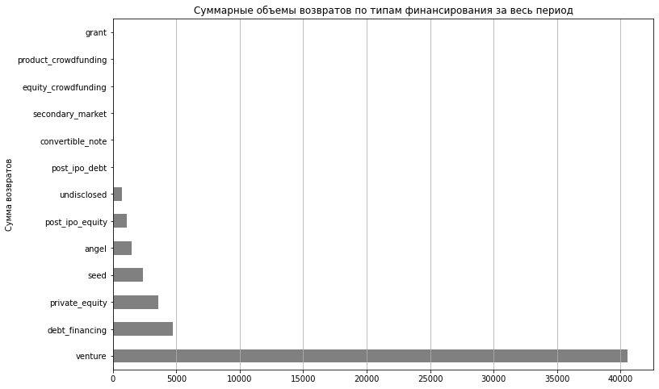

```python
# Строим линейчатую диаграмму
total_returns.plot(kind='barh',
    title='Суммарные объемы возвратов по типам финансирования за весь период',
    legend=False,
    xlabel='Сумма возвратов',
    ylabel='Тип финансирования',
    figsize=(12, 8),
    rot=0,
    color='gray')

plt.grid(axis='x')

plt.show()
```

Теперь, сравним типы финансирования в разрезе популярности, объемности и возвратности.

Объеденим все в одну таблицу:

```python
# Объединим в один датафрейм
analysis_df = pd.DataFrame({
    'volume': funding_volume,
    'popularity': funding_popularity,
    'returns': total_returns
})

analysis_df = analysis_df.sort_values('volume', ascending=False)

analysis_df
```

|  | volume | popularity | returns |
| --- | --- | --- | --- |
| venture | 1.290734e+11 | 18835 | 40578.62 |
| seed | 9.435951e+09 | 13368 | 2382.24 |
| debt_financing | 8.193778e+09 | 3269 | 4734.85 |
| private_equity | 4.830725e+09 | 636 | 3587.33 |
| angel | 2.477724e+09 | 2934 | 1509.23 |
| undisclosed | 2.088889e+09 | 814 | 730.88 |
| grant | 2.002124e+09 | 1005 | 0.00 |
| post_ipo_equity | 1.930552e+09 | 163 | 1104.96 |
| convertible_note | 5.660394e+08 | 521 | 34.79 |
| post_ipo_debt | 2.867183e+08 | 27 | 91.03 |
| equity_crowdfunding | 2.379606e+08 | 515 | 3.83 |
| product_crowdfunding | 1.833103e+08 | 204 | 1.86 |
| secondary_market | 4.528580e+07 | 7 | 5.20 |

Теперь, построим график типа "Scatter", где:

- По оси X - популярность
- По оси Y - объём инвестиций
- Размер круга - возвраты

[figure not shown]

```python
# Задаем размер графика
plt.figure(figsize=(16, 12))

# Строим график  с использованием plt.catter()
plt.scatter(funding_popularity, funding_volume, alpha=0.6, s=analysis_df['returns'] * 0.7)

# Подписи
for i in range(len(funding_popularity)):
    plt.text(funding_popularity[i], funding_volume[i], funding_popularity.index[i])

plt.xlabel('Популярность (количество компаний)')
plt.ylabel('Суммарный объём инвестиций')
plt.title('Сравнение типов финансирования: популярность и объём')

# Диагональная линия
max_val = max(funding_popularity.max(), funding_volume.max())
plt.plot([0, funding_popularity.max()], [0, funding_volume.max()], linestyle='-')

# Добавляем сетку
plt.grid()

# Добавляем логарифмическую шкалу, чтобы данные не съехали
plt.xscale('log')
plt.yscale('log')

# Показываем график
plt.show()
```

По диаграмме видно, что типы финансирования распределены неравномерно по соотношению популярности и объёма.

`Venture` явно доминирует - он одновременно самый популярный и самый объёмный тип финансирования. Это основной инструмент привлечения крупных инвестиций на рынке.

Напротив, существуют типы, которые встречаются реже, но характеризуются значительным объёмом финансирования. К ним можно отнести `debt_financing` и `private_equity` - их популярность ниже, чем у `seed`, однако объёмы привлечённых средств сопоставимо высоки. Это указывает на использование данных инструментов в более зрелых компаниях и для крупных сделок.

Такие типы, как `post_ipo_equity`, `post_ipo_debt` и `secondary_market`, используются относительно редко и при этом не демонстрируют высоких объёмов в рамках рассматриваемого периода.

## Шаг 4. Анализ динамики

### 4.1 Динамика предоставления финансирования по годам

Используя столбцы `funding_total_usd` и `funding_rounds`, рассчитаем для каждой компании средний объём одного раунда финансирования.

```python
# Рассчитаем средний объём одного раунда финансирования для каждой компании
df_final['avg_round_usd'] = df_final['funding_total_usd'] / df_final['funding_rounds']

# Проверим результат:
df_final.head(5)
```

|  | name | homepage_url | category_list | market | funding_total_usd | status | country_code | state_code | region | city | ... | round_c | round_d | round_e | round_f | round_g | round_h | funding_group | is_outlier | funding_year | avg_round_usd |
| --- | --- | --- | --- | --- | --- | --- | --- | --- | --- | --- | --- | --- | --- | --- | --- | --- | --- | --- | --- | --- | --- |
| 1 | University of New Brunswick | http://www.unb.ca | Неизвестно | niche | 2000000.0 | operating | Неизвестно | Неизвестно | Неизвестно | Неизвестно | ... | 0.0 | 0.0 | 0.0 | 0.0 | 0.0 | 0.0 | Единичное финансирование | False | 2014 | 2.000000e+06 |
| 2 | DuPont | http://www.dupont.com | \|Business Services\|Agriculture\|Automotive\|Inve... | mid | 9000000.0 | operating | USA | DE | Wilmington, Delaware | Wilmington | ... | 0.0 | 0.0 | 0.0 | 0.0 | 0.0 | 0.0 | Единичное финансирование | False | 2009 | 9.000000e+06 |
| 3 | University of Michigan | http://www.umich.edu/ | \|Education\| | education | 7700000.0 | operating | USA | MI | Detroit | Ann Arbor | ... | 0.0 | 0.0 | 0.0 | 0.0 | 0.0 | 0.0 | Срок финансирования до года | False | 2013 | 2.566667e+06 |
| 4 | Case Western Reserve University | http://www.case.edu | \|Education\| | education | 540000.0 | operating | USA | OH | Cleveland | Cleveland | ... | 0.0 | 0.0 | 0.0 | 0.0 | 0.0 | 0.0 | Единичное финансирование | False | 2014 | 5.400000e+05 |
| 7 | Duke University | http://www.duke.edu | \|Education\| | education | 8700000.0 | operating | USA | NC | Raleigh | Durham | ... | 0.0 | 0.0 | 0.0 | 0.0 | 0.0 | 0.0 | Единичное финансирование | False | 2014 | 8.700000e+06 |

5 rows × 44 columns

На основе получившейся таблицы построим график, отражающий динамику типичного размера средств, которые стартапы получали в рамках одного раунда финансирования.

Для этого нужно сгруппировать данные по годам и вычислить среднее значение размера одного раунда для каждого года.

```python
# Группируем по году и рассчитываем средний размер одного раунда
avg_rounds_per_year = df_final.groupby('funding_year')['avg_round_usd'].mean()

avg_rounds_per_year
```

```
funding_year
2000    4.444172e+06
2001    3.330367e+06
2002    4.053461e+06
2003    3.099490e+06
2004    4.616702e+06
2005    5.801089e+06
2006    5.344284e+06
2007    4.673053e+06
2008    4.327268e+06
2009    3.522236e+06
2010    3.196218e+06
2011    2.598013e+06
2012    2.040344e+06
2013    1.975319e+06
2014    2.190701e+06
Name: avg_round_usd, dtype: float64
```

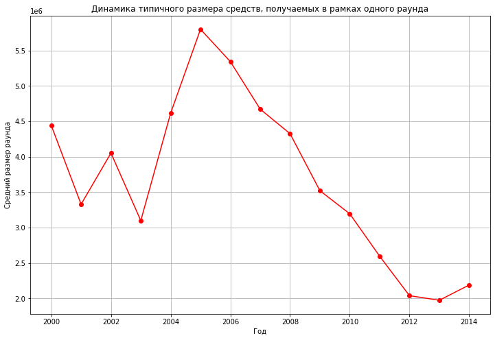

```python
# Строим график динамики средних размеров раундов
plt.figure(figsize=(12, 8))
plt.plot(avg_rounds_per_year.index, avg_rounds_per_year.values, marker='o', linestyle='-', color='r')
plt.title('Динамика типичного размера средств, получаемых в рамках одного раунда')
plt.xlabel('Год')
plt.ylabel('Средний размер раунда')
plt.grid(True)

# Выводим график
plt.show()
```

Судя по графику, типичный размер средств, привлекаемых стартапами в рамках одного раунда финансирования, изменялся неравномерно на протяжении анализируемого периода.Максимальное значение среднего размера одного раунда было зафиксировано в 2005 году. В последующие годы наблюдалось снижение среднего размера раунда.

Также, построим график, отражающий динамику общего количества раундов за каждый год, то есть насколько активно происходили инвестиции на рынке (чем больше раундов, тем выше активность).

Для этого нужно сначала подсчитать общее количество раундов для каждого года и затем построить график.

```python
# Группируем по году и считаем общее количество раундов
rounds_per_year = df_final.groupby('funding_year')['funding_rounds'].sum()

rounds_per_year
```

```
funding_year
2000      112.0
2001       66.0
2002       98.0
2003      125.0
2004      181.0
2005      948.0
2006     1852.0
2007     2839.0
2008     3666.0
2009     4627.0
2010     6145.0
2011     7570.0
2012     9724.0
2013    12869.0
2014     7115.0
Name: funding_rounds, dtype: float64
```

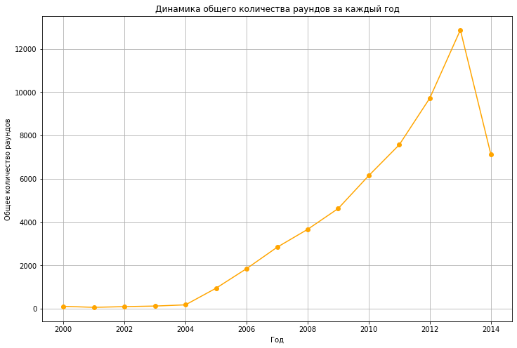

```python
# Строим график динамики общего количества раундов
plt.figure(figsize=(12, 8))
plt.plot(rounds_per_year.index, rounds_per_year.values, marker='o', linestyle='-', color='orange')
plt.title('Динамика общего количества раундов за каждый год')
plt.xlabel('Год')
plt.ylabel('Общее количество раундов')
plt.grid(True)

# Выводим график
plt.show()
```

Максимальный типичный размер средств, привлекаемых в одном раунде финансирования, был зафиксирован в 2005 году.

### 4.2 Динамика размера общего финансирования по массовым сегментам рынка для растущих в 2014 году сегментов

Составим сводную таблицу, в которой укажем суммарный размер общего финансирования `funding_total_usd` по годам и сегментам рынка. Отберем из нее только те сегменты, которые показывали рост размера суммарного финансирования в 2014 году по сравнению с 2013.

```python
# Считаем суммарный объем финансирования по годам и сегментам рынка
funding_by_year_market = (df_final.groupby(['funding_year', 'market'])['funding_total_usd'].sum().reset_index())
```

```python
# Отбираем только массовые сегменты рынка
funding_by_year_market_mass = funding_by_year_market[funding_by_year_market['market'].isin(['mid', 'niche']) == False]
```

```python
# Преобразуем таблицу для удобного сравнения годов
pivot_funding = (funding_by_year_market_mass.pivot(index='market',
                                                   columns='funding_year',
                                                   values='funding_total_usd'))

# Выводим сводную таблицу
pivot_funding
```

| funding_year market | 2000 | 2001 | 2002 | 2003 | 2004 | 2005 | 2006 | 2007 | 2008 | 2009 | 2010 | 2011 | 2012 | 2013 | 2014 |
| --- | --- | --- | --- | --- | --- | --- | --- | --- | --- | --- | --- | --- | --- | --- | --- |
| advertising | 14470000.0 | 8778321.0 | 24500000.0 | 10500000.0 | 6000000.0 | 127196022.0 | 2.992995e+08 | 5.567043e+08 | 6.226735e+08 | 5.634460e+08 | 6.316179e+08 | 4.107307e+08 | 5.211370e+08 | 5.249151e+08 | 2.077923e+08 |
| analytics | 14822803.0 | NaN | 7500000.0 | 3840000.0 | 3000000.0 | 79014044.0 | 1.397013e+08 | 9.882900e+07 | 2.080778e+08 | 1.409493e+08 | 2.537399e+08 | 4.433334e+08 | 5.392143e+08 | 6.228214e+08 | 1.514616e+08 |
| apps | NaN | NaN | NaN | NaN | NaN | NaN | 1.310600e+06 | NaN | 4.300000e+06 | 7.219000e+06 | 6.123779e+06 | 1.837407e+07 | 3.260112e+07 | 2.886862e+07 | 6.623773e+07 |
| automotive | NaN | NaN | NaN | 4530000.0 | NaN | 22500000.0 | 1.266000e+07 | 3.771260e+07 | 5.947864e+07 | 2.080031e+07 | 1.769692e+07 | 7.645216e+07 | 3.555768e+07 | 1.175725e+08 | 6.903416e+07 |
| big data | NaN | NaN | NaN | NaN | NaN | NaN | NaN | 7.780000e+06 | 2.452515e+06 | 5.973750e+05 | 3.923330e+07 | 6.036916e+07 | 8.641334e+07 | 7.869892e+07 | 7.923260e+07 |
| biotechnology | NaN | NaN | NaN | 85531178.0 | 97184859.0 | 480063583.0 | 9.035005e+08 | 1.704078e+09 | 1.716033e+09 | 3.915901e+09 | 4.894500e+09 | 4.967552e+09 | 4.931139e+09 | 5.694270e+09 | 2.509639e+09 |
| clean technology | NaN | NaN | 34390435.0 | 50352939.0 | 50427954.0 | 19420000.0 | 1.314739e+08 | 7.497112e+08 | 3.165808e+09 | 1.963503e+09 | 1.604429e+09 | 1.545603e+09 | 9.580112e+08 | 1.203061e+09 | 6.886868e+08 |
| cloud computing | 11500000.0 | NaN | NaN | NaN | NaN | NaN | 9.951809e+06 | 2.035434e+07 | 4.437500e+07 | 5.222372e+07 | 8.525538e+06 | 7.315140e+07 | 7.442158e+07 | 8.484678e+07 | 7.344086e+07 |
| consulting | 4500000.0 | NaN | NaN | NaN | NaN | 44862000.0 | 2.396555e+07 | 7.034634e+07 | 1.906108e+07 | 6.271516e+07 | 8.126488e+07 | 4.341340e+07 | 6.592276e+07 | 9.332132e+07 | 5.429802e+07 |
| curated web | 1000000.0 | 305000.0 | 4650000.0 | 2550000.0 | 27050000.0 | 53450000.0 | 1.646737e+08 | 3.263045e+08 | 3.365000e+08 | 2.613605e+08 | 3.470186e+08 | 2.999183e+08 | 3.564772e+08 | 4.664954e+08 | 2.417543e+08 |
| design | NaN | NaN | NaN | NaN | NaN | 9300000.0 | 7.070000e+05 | 1.080000e+07 | 5.944302e+06 | 2.150144e+06 | 1.723998e+07 | 8.899967e+06 | 3.963069e+07 | 6.095884e+07 | 6.898852e+07 |
| e-commerce | 32879052.0 | 8800000.0 | 3000000.0 | NaN | 1505741.0 | 10568620.0 | 1.112227e+08 | 8.778439e+07 | 1.773982e+08 | 2.155966e+08 | 4.412108e+08 | 5.245095e+08 | 6.977342e+08 | 8.744076e+08 | 5.337287e+08 |
| education | NaN | 200000.0 | 1469542.0 | 2500000.0 | 1350000.0 | 4751000.0 | 9.511823e+06 | 3.028300e+07 | 8.501275e+07 | 6.807854e+07 | 1.573842e+08 | 1.234421e+08 | 2.562888e+08 | 3.843112e+08 | 2.310033e+08 |
| enterprise software | 4711445.0 | 2180175.0 | 52100995.0 | 7669661.0 | 4500000.0 | 320413544.0 | 8.282883e+08 | 9.559736e+08 | 9.916643e+08 | 8.397618e+08 | 1.257557e+09 | 9.909051e+08 | 1.078626e+09 | 1.075400e+09 | 1.665429e+08 |
| entertainment | 100000.0 | NaN | NaN | NaN | NaN | 10000000.0 | 1.800000e+06 | 3.122402e+07 | 3.360000e+07 | 1.106958e+07 | 1.719761e+07 | 4.416827e+07 | 1.668800e+07 | 7.003140e+07 | 6.343818e+07 |
| fashion | NaN | NaN | NaN | 9800000.0 | NaN | NaN | 2.620000e+06 | 2.000000e+06 | 3.424688e+07 | 4.906540e+07 | 1.568340e+08 | 8.835950e+07 | 1.724564e+08 | 1.674116e+08 | 1.110752e+08 |
| finance | 15000000.0 | NaN | NaN | 25320000.0 | NaN | 48235001.0 | 1.858398e+08 | 3.717047e+08 | 3.148764e+08 | 2.353044e+08 | 4.467984e+08 | 5.051004e+08 | 4.930980e+08 | 8.477627e+08 | 4.663268e+08 |
| games | 21728774.0 | 5000000.0 | 5025000.0 | 11348830.0 | 38150000.0 | 86626921.0 | 2.898921e+08 | 5.636316e+08 | 4.351724e+08 | 3.503774e+08 | 3.867970e+08 | 3.726352e+08 | 4.496741e+08 | 3.068205e+08 | 1.855324e+08 |
| hardware + software | NaN | NaN | 8000000.0 | 12200000.0 | 14775000.0 | 280865552.0 | 4.117540e+08 | 4.924714e+08 | 2.989313e+08 | 5.252338e+08 | 4.840781e+08 | 5.496816e+08 | 5.078471e+08 | 8.035850e+08 | 2.822954e+08 |
| health and wellness | 11900000.0 | NaN | 795650.0 | 3414041.0 | NaN | 30210000.0 | 2.077000e+07 | 6.682840e+07 | 1.746778e+07 | 2.043128e+08 | 2.240608e+08 | 4.111617e+08 | 3.784288e+08 | 5.845244e+08 | 3.806186e+08 |
| health care | 16000000.0 | 125000.0 | 20309671.0 | NaN | 22219087.0 | 111091410.0 | 6.230567e+08 | 8.060546e+08 | 1.029157e+09 | 1.643318e+09 | 1.990032e+09 | 2.205131e+09 | 1.883600e+09 | 1.740842e+09 | 5.692177e+08 |
| hospitality | NaN | NaN | NaN | NaN | NaN | 1020480.0 | 1.465581e+07 | 1.354717e+07 | 6.544195e+06 | 3.130958e+07 | 4.965043e+07 | 9.934630e+07 | 1.139272e+08 | 2.699438e+08 | 1.485565e+08 |
| internet | 10000000.0 | NaN | 1100000.0 | NaN | 10500000.0 | 1775000.0 | 5.000000e+03 | 4.495379e+06 | 2.341296e+07 | 3.819577e+07 | 3.665750e+07 | 3.685903e+07 | 2.828868e+07 | 6.973210e+07 | 1.178308e+08 |
| manufacturing | 56659310.0 | 2368582.0 | NaN | 4269608.0 | 3000000.0 | 61770000.0 | 1.639578e+08 | 1.477261e+08 | 1.730543e+08 | 4.228625e+08 | 2.443297e+08 | 5.616393e+08 | 5.222052e+08 | 3.939366e+08 | 4.163323e+08 |
| marketplaces | NaN | 105000.0 | NaN | NaN | NaN | NaN | NaN | 4.145720e+06 | 2.710000e+06 | 1.938668e+06 | 7.249013e+06 | 1.053327e+07 | 2.644131e+07 | 4.278189e+07 | 2.893440e+07 |
| medical | 24000000.0 | NaN | NaN | NaN | NaN | 11090000.0 | 2.025000e+07 | 2.100000e+06 | 2.881274e+07 | 1.156620e+07 | 2.559034e+07 | 2.854096e+07 | 4.403960e+07 | 6.446942e+07 | 1.752361e+08 |
| messaging | NaN | NaN | 10000000.0 | NaN | 13300000.0 | 115917020.0 | 1.451338e+08 | 7.527010e+07 | 6.785460e+07 | 4.981101e+07 | 5.971695e+07 | 1.370811e+08 | 5.033503e+07 | 2.886401e+07 | 2.093229e+07 |
| mobile | 10000000.0 | NaN | 11654597.0 | 8010058.0 | 69822132.0 | 219894870.0 | 3.472758e+08 | 4.059717e+08 | 5.503751e+08 | 4.870592e+08 | 5.667935e+08 | 7.665884e+08 | 9.301256e+08 | 1.191993e+09 | 5.756398e+08 |
| music | NaN | NaN | NaN | NaN | NaN | 9970000.0 | 5.646688e+07 | 6.103384e+07 | 5.024857e+07 | 3.293788e+07 | 2.964120e+07 | 4.718299e+07 | 2.316412e+07 | 6.094648e+07 | 3.232037e+07 |
| networking | NaN | NaN | NaN | NaN | NaN | NaN | 2.688985e+07 | 4.374572e+07 | 3.080700e+07 | 3.022741e+07 | 4.618220e+07 | 1.324181e+07 | 7.670913e+07 | 6.744830e+07 | 6.140726e+07 |
| news | NaN | NaN | 1000000.0 | 1000000.0 | NaN | 9590000.0 | 3.711657e+07 | 6.094104e+07 | 8.741601e+07 | 4.863580e+07 | 1.039456e+08 | 4.354941e+07 | 1.001543e+08 | 7.212919e+07 | 4.947865e+07 |
| nonprofits | 6500000.0 | NaN | NaN | NaN | NaN | 17051520.0 | 1.288000e+07 | 2.000000e+05 | 7.110739e+06 | 4.766000e+06 | 1.535498e+07 | 3.502556e+07 | 2.403932e+07 | 7.115546e+07 | 5.434130e+07 |
| photography | NaN | NaN | NaN | 7100000.0 | NaN | 7000000.0 | 6.686406e+06 | 1.011500e+07 | 2.054932e+07 | 3.577586e+07 | 1.739748e+07 | 3.326497e+07 | 4.436560e+07 | 5.003385e+07 | 4.789785e+07 |
| public relations | NaN | NaN | NaN | NaN | NaN | 79695875.0 | 3.860000e+07 | 2.851000e+07 | 3.329562e+07 | 6.072834e+07 | 2.789598e+07 | 3.339201e+07 | 2.460205e+07 | 3.733820e+07 | 2.368066e+07 |
| real estate | 2500000.0 | NaN | 5275000.0 | 6292200.0 | NaN | 250000.0 | 2.080000e+06 | 3.322000e+07 | 4.661310e+07 | 3.884021e+07 | 3.734461e+07 | 2.001513e+07 | 7.732086e+07 | 9.220766e+07 | 1.155674e+08 |
| saas | NaN | NaN | 2000000.0 | NaN | NaN | 5240000.0 | 4.791121e+06 | 1.465260e+07 | 2.662690e+07 | 1.353658e+07 | 3.260939e+07 | 3.222375e+07 | 4.969991e+07 | 7.957661e+07 | 9.280775e+07 |
| search | 2001000.0 | NaN | NaN | 5000000.0 | 10800000.0 | 11800000.0 | 3.782172e+07 | 4.963955e+07 | 5.930430e+07 | 2.717343e+07 | 3.148633e+07 | 5.390936e+07 | 3.930401e+07 | 7.917338e+07 | 4.036931e+07 |
| security | 20211700.0 | 26380000.0 | 61714000.0 | 13650000.0 | 68350000.0 | 333759701.0 | 2.379433e+08 | 3.969962e+08 | 4.539290e+08 | 3.612376e+08 | 3.181183e+08 | 2.539945e+08 | 3.196214e+08 | 4.159446e+08 | 1.799674e+08 |
| semiconductors | NaN | 101727992.0 | NaN | 28000000.0 | 88782797.0 | 586220751.0 | 1.227941e+09 | 1.616604e+09 | 1.107199e+09 | 1.434207e+09 | 7.678236e+08 | 2.475882e+08 | 1.856072e+08 | 3.647047e+08 | 2.267494e+08 |
| social media | NaN | 650000.0 | NaN | 5000.0 | 6850000.0 | 14780000.0 | 6.016988e+07 | 8.902252e+07 | 7.603453e+07 | 6.003326e+07 | 6.944720e+07 | 1.460043e+08 | 2.080228e+08 | 1.797983e+08 | 7.889491e+07 |
| social network media | NaN | NaN | NaN | NaN | NaN | 5200000.0 | 5.245100e+06 | 2.410402e+07 | 1.099808e+07 | 9.451188e+06 | 2.404342e+07 | 1.527149e+07 | 2.224020e+07 | 2.591774e+07 | 2.507531e+07 |
| software | 31732640.0 | 27811352.0 | 101026395.0 | 66086037.0 | 140823795.0 | 993076581.0 | 1.646869e+09 | 1.686116e+09 | 1.365006e+09 | 1.254335e+09 | 1.520172e+09 | 1.533295e+09 | 1.797266e+09 | 1.949166e+09 | 1.352586e+09 |
| sports | NaN | NaN | 200000.0 | NaN | NaN | 1882200.0 | 7.000000e+06 | 1.640158e+07 | 9.554790e+06 | 1.180875e+07 | 3.818499e+07 | 1.628426e+07 | 4.099387e+07 | 3.620852e+07 | 3.345651e+07 |
| startups | NaN | NaN | NaN | NaN | NaN | NaN | NaN | NaN | 5.010387e+06 | 4.607000e+05 | 2.111966e+06 | 1.965440e+07 | 1.235878e+07 | 1.808055e+07 | 4.150184e+07 |
| technology | NaN | 22160000.0 | 11000000.0 | NaN | 1750000.0 | 50728425.0 | 2.279100e+07 | 1.801902e+08 | 2.777262e+08 | 3.607885e+07 | 3.125268e+08 | 1.432227e+08 | 1.933349e+08 | 1.208739e+08 | 2.020189e+08 |
| travel | 50230.0 | NaN | NaN | NaN | 10230000.0 | 27830000.0 | 1.170000e+07 | 1.395000e+07 | 5.490563e+07 | 2.453647e+07 | 4.446181e+07 | 7.759961e+07 | 7.629628e+07 | 1.621239e+08 | 7.892027e+07 |
| video | NaN | NaN | NaN | 5000000.0 | 14704000.0 | 6470551.0 | 3.517177e+07 | 8.515064e+07 | 3.786518e+07 | 2.230558e+07 | 7.997420e+07 | 2.633212e+07 | 5.496847e+07 | 6.822211e+07 | 5.443771e+07 |
| web hosting | 95343090.0 | 15000000.0 | NaN | NaN | 27000000.0 | 483332632.0 | 6.499593e+08 | 3.611214e+08 | 7.816237e+08 | 4.711310e+08 | 5.344805e+08 | 3.079390e+08 | 1.885812e+08 | 4.669258e+08 | 5.665238e+07 |

```python
# Оставляем сегменты с ростом в 2014 году относительно 2013
growing_markets_2014 = pivot_funding[(pivot_funding[2014] > pivot_funding[2013])].index

# Фильтруем исходную таблицу
funding_growth_2014 = funding_by_year_market_mass[funding_by_year_market_mass['market'].isin(growing_markets_2014)]
```

```python
# Оставляем только активные годы
funding_growth_2014 = funding_growth_2014[funding_growth_2014['funding_year'].isin(active_years)]
```

На графике отразим, как менялся суммарный размер общего финансирования в каждом из отобранных сегментов по годам, за которые у нас достаточно данных.

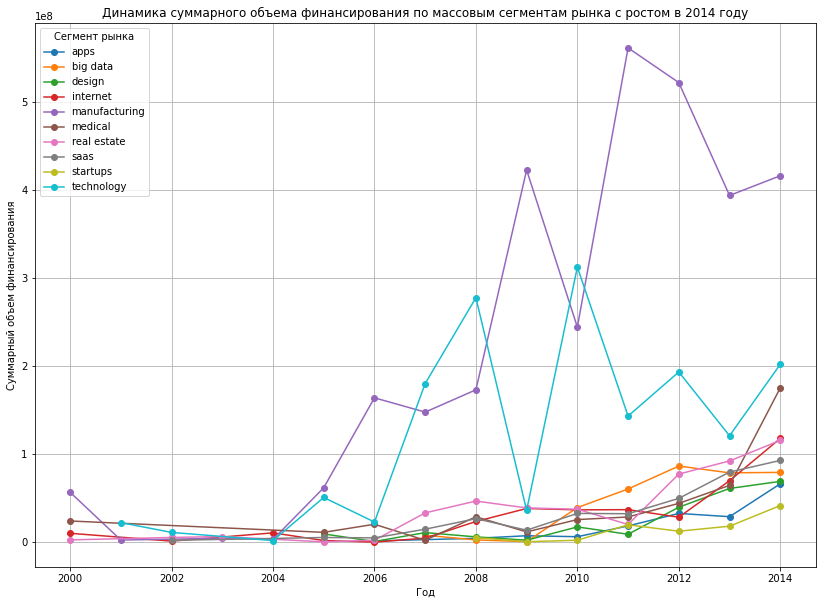

```python
plt.figure(figsize=(14, 10))

for market in growing_markets_2014:
    data = funding_growth_2014[funding_growth_2014['market'] == market]
    plt.plot(data['funding_year'],
        data['funding_total_usd'],
        marker='o',
        label=market)

# Добавляем заголовок графика и подписи для осей
plt.title('Динамика суммарного объема финансирования по массовым сегментам рынка с ростом в 2014 году')
plt.xlabel('Год')
plt.ylabel('Суммарный объем финансирования')

# Добавляем легенду и сетку
plt.legend(title='Сегмент рынка')
plt.grid(True)

plt.show()
```

### 4.3 Годовая динамика доли возвращённых средств по типам финансирования

Нам необходимо для каждого года и каждого вида финансирования рассчитать нормированные значения возврата средств: то есть какую долю возвращённые средства составляют от предоставленных. При этом слишком большие аномальные значения, то есть неадекватные выбросы, нужно заменить на пропуски.

```python
# Считаем суммарный объём привлечённого финансирования по годам и типам
# Список типов финансирования
funding_types_2 = ['venture','debt_financing','private_equity','seed','angel']

# Считаем суммарный объем привлеченных средств по годам
funding_by_year = (df_final.groupby('funding_year')[funding_types_2].sum().reset_index().rename(columns={'funding_year': 'year'}))
```

```python
# Приводим возвраты к тем же единицам измерения (USD):
# Копируем таблицу возвратов
returns = cb_returns[funding_types].copy()

# Переводим миллионы долларов в доллары
returns[funding_types] = returns[funding_types] * 1_000_000

# Переносим индекс в столбец для объединения
returns = returns.reset_index().rename(columns={'index': 'year'})
```

```python
# Объединяем инвестиции и возвраты по годам
merged_df = funding_by_year.merge(returns,on='year',suffixes=('_funding', '_returns'))
```

```python
# Считаем нормированную долю возврата средств (с защитой от деления на ноль)
# Малое число для защиты от деления на ноль
for ftype in funding_types_2:
    merged_df[f'{ftype}_ratio'] = (merged_df[f'{ftype}_returns'] / (merged_df[f'{ftype}_funding'] + 1e-60))
```

```python
# Убираем аномальные выбросы (слишком большие значения)
# Используем IQR-метод отдельно для каждого типа финансирования:
for ftype in funding_types_2:
    ratio_col = f'{ftype}_ratio'

    Q1 = merged_df[ratio_col].quantile(0.25)
    Q3 = merged_df[ratio_col].quantile(0.75)
    IQR = Q3 - Q1

    upper_bound = Q3 + 1.5 * IQR

    # Заменяем аномалии на NaN
    merged_df.loc[merged_df[ratio_col] > upper_bound, ratio_col] = None
```

Построим график, на котором отобразим нормированные значения возврата средств для типов финансирования `venture`, `debt_financing`, `private_equity`, `seed` и `angel`.

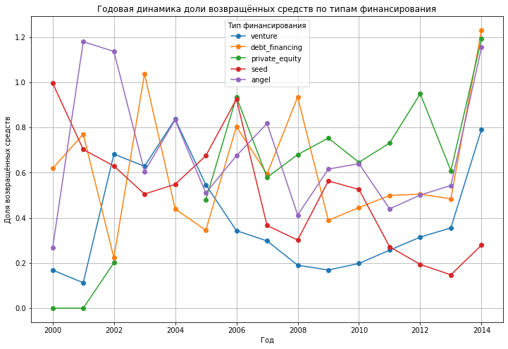

```python
# Строим график нормированных значений возврата средств
plt.figure(figsize=(12, 8))

for ftype in funding_types_2:
    plt.plot(
        merged_df['year'],
        merged_df[f'{ftype}_ratio'],
        marker='o',
        label=ftype)

# Добавляем заголовок графика и подписи для осей
plt.title('Годовая динамика доли возвращённых средств по типам финансирования')
plt.xlabel('Год')
plt.ylabel('Доля возвращённых средств')

# Добавляем легенду и сетку
plt.legend(title='Тип финансирования')
plt.grid(True)

plt.show()
```

Angel-финансирование демонстрирует умеренный рост в отдельные годы, но без устойчивой положительной динамики на всём временном интервале.

## Шаг 5. Итоговый вывод и рекомендации

### 5.1. Рекомендации заказчику

Таким образом, стратегия инвестирования в сегмент Technology с использованием инвестиций в виде прямых вложений может рассматриваться как наиболее сбалансированная с точки зрения потенциала роста и возвратности вложенных средств.

### 5.2. Итоги проекта

В процессе выполнения проекта была проделана следующая работа:

#### Предобработка данных

1. Загрузка и первичный анализ данных
   - Были загружены датасеты `cb_investments` и `cb_returns`;
   - Изучена общая структура данных, объём датасетов, типы данных и наличие пропусков;
   - Проверено соответствие данных описанию проекта.
2. Приведение данных к корректным типам
   - В столбце `funding_total_usd` удалено разделение разрядов, значения приведены к числовому типу;
   - Столбцы с датами (`founded_at`, `first_funding_at`, `mid_funding_at`, `last_funding_at`) приведены к формату datetime;
   - В датасете `cb_returns` столбец year был использован в качестве индекса.
3. Обработка пропусков и дубликатов
   - Удалены строки без информации о финансировании и строки с пропусками в `funding_total_usd`;
   - Обработаны полные дубликаты;
   - Пропуски в столбце `mid_funding_at` были заполнены значением, соответствующим середине интервала между первым и последним раундом финансирования;
   - Текстовые пропуски были заполнены заглушками при необходимости.

**Результаты предобработки:**

Было строк в исходном датасете: 54294;

Осталось строк после обработки: 40894;

Удалено строк: 13400;

Процент потерь данных: 24.68%.

Сделан вывод о том, что объём и качество оставшихся данных достаточны для дальнейшего анализа.

#### Инжиниринг признаков и исследовательский анализ

1. Компании были разделены на три группы по срокам финансирования:
- с единичным раундом;
- со сроком финансирования до года;
- со сроком финансирования более года;
1. Для этих групп было проанализировано распределение как по количеству компаний, так и по объёму привлечённых средств.
2. Сегменты рынка были разделены на массовые, средние и нишевые в зависимости от количества компаний. Средние и нишевые сегменты были объединены в группы mid и niche, а дальнейший анализ проводился только для массовых сегментов.
3. Были выявлены аномальные значения общего объёма финансирования с использованием метода IQR отдельно для каждого сегмента рынка. Компании с аномальным объёмом финансирования были исключены из дальнейшего анализа.
4. Определены годы с высокой инвестиционной активностью (50 и более раундов финансирования), и анализ динамики проводился только для этих периодов.

#### Анализ типов финансирования

1. Были проанализированы суммарные объёмы привлечённых средств по различным типам финансирования;
2. Исследована популярность типов финансирования по частоте использования компаниями;
3. Выявлены типы финансирования, которые используются часто, но характеризуются небольшими объёмами, а также редкие, но капиталоёмкие формы финансирования;
4. Дополнительно изучены суммарные объёмы возвратов по каждому типу финансирования за весь период.

#### Выводы и рекомендации

В целом результаты анализа согласуются между собой: сегменты с ростом инвестиционной активности, как правило, сопровождаются более устойчивыми показателями возвратности.